# Confirmatory analysis

```r
install.packages("https://cran.r-project.org/src/contrib/Archive/MissMech/MissMech_1.0.2.tar.gz", repos=NULL, type="source")
install.packages("moments")
library(psych)
library(naniar)
library(sjlabelled)
library(tidyverse)
library(mice)
library(VIM)
library(MissMech)
library(mice)
library(MoEClust)
library(miceadds)
library(readr)
library(lavaan)
library(semPlot)
library(dplyr)
library(tidyverse)
library(Hmisc)
library(mosaic)
library(psych)
library(moments)
```

#load data

Data can be found in the appendices folder of the compendium.

```r
IRP<- read_csv("C:/Users/hanam/OneDrive/Desktop/202100114- Research Compendium/Appendices/IRP.csv")
head(IRP)
```

| consent sheet_Id | gender | IM1 | IM2 | IM3 | IM4 | IM5 | IM6 | IM7 | IM8 | IM9 | IM10 | IM11 | IM12 | IM13 | IM14 | IM15 | IM16 | IM17 | HC1 | HC2 | HC3 | HC4 | VC1 | VC2 | VC3 | VC4 | HI1 | HI2 | HI3 | … |
| --- | --- | --- | --- | --- | --- | --- | --- | --- | --- | --- | --- | --- | --- | --- | --- | --- | --- | --- | --- | --- | --- | --- | --- | --- | --- | --- | --- | --- | --- | --- |
| F_11cnxcO2hEdklM9 | 2 | 1 | 0 | 1 | 1 | 1 | 1 | 1 | 1 | 1 | 0 | 1 | 0 | 1 | 0 | 1 | 0 | 1 | 7 | 7 | 6 | 6 | 8 | 6 | 7 | 7 | 8 | 8 | 7 | … |
| F_XoInUSCpYUzcGHv | 2 | 0 | 0 | 1 | 1 | 0 | 0 | 0 | 0 | 1 | 1 | 0 | 1 | 1 | 1 | 0 | 0 | 0 | 2 | 6 | 4 | 4 | 4 | 2 | 5 | 5 | 7 | 4 | 3 | … |
| F_2tJWSVQ3q6BTJwx | 2 | 1 | 1 | 0 | 1 | 1 | 0 | 1 | 1 | 1 | 1 | 1 | 1 | 1 | 1 | 1 | 1 | 1 | 7 | 5 | 8 | 7 | 8 | 7 | 6 | 6 | 9 | 9 | 9 | … |
| F_1r05aGMdLqQ7Cda | 2 | 1 | 1 | 1 | 0 | 1 | 0 | 0 | 1 | 0 | 1 | 0 | 1 | 1 | 1 | 0 | 0 | 0 | 6 | 6 | 6 | 5 | 6 | 6 | 6 | 7 | 5 | 4 | 4 | … |
| F_2Tw2PtpWZ6zPsHE | 1 | 0 | 0 | 0 | 1 | 1 | 0 | 0 | 1 | 1 | 1 | 0 | 0 | 1 | 1 | 0 | 0 | 0 | 7 | 5 | 7 | 7 | 7 | 7 | 4 | 6 | 8 | 8 | 8 | … |
| F_1IQVmniCjQzUgh4 | 2 | 1 | 0 | 1 | 1 | 1 | 0 | 1 | 1 | 1 | 1 | 1 | 0 | 1 | 1 | 0 | 0 | 1 | 7 | 6 | 7 | 7 | 7 | 7 | 7 | 7 | 7 | 7 | 8 | … |

#data screening and cleaning

Determining the amount and pattern of missing data.

```
 /\     /\
{  `---'  }
{  O   O  }
==>  V <==  No need for mice. This data set is completely observed.
 \  \|/  /
  `-----'

    consent sheet_Id gender IM1 IM2 IM3 IM4 IM5 IM6 IM7 IM8
127                1      1   1   1   1   1   1   1   1   1
                   0      0   0   0   0   0   0   0   0   0
    IM9 IM10 IM11 IM12 IM13 IM14 IM15 IM16 IM17 HC1 HC2 HC3
127   1    1    1    1    1    1    1    1    1   1   1   1
      0    0    0    0    0    0    0    0    0   0   0   0
    HC4 VC1 VC2 VC3 VC4 HI1 HI2 HI3 HI4 VI1 VI2 VI3 VI4 P1 P2
127   1   1   1   1   1   1   1   1   1   1   1   1   1  1  1
      0   0   0   0   0   0   0   0   0   0   0   0   0  0  0
    P3 P4 P5 P6 P7 P8 LS1 LS2 LS3 LS4 LS5
127  1  1  1  1  1  1   1   1   1   1   1 0
     0  0  0  0  0  0   0   0   0   0   0 0
```

[figure not shown]

```r
IRP_var <-
  IRP %>%
  select(3:48) # select out only the items
md.pattern(IRP)
```

dataset is fully observed

this is calculating the means of specific sets of variables

```r
IRP <-
  IRP %>%
  rowwise()%>%
  mutate(meancollectivism = mean(c(HC1, HC2, HC3, HC4, VC1, VC2, VC3, VC4))) %>%
  mutate(meanperfectionism = mean(c(P1, P2, P3, P4, P5, P6, P7, P8))) %>%
  mutate(meanim = mean(c(IM1, IM2, IM3, IM4, IM5, IM6, IM7, IM8, IM9, IM10, IM11, IM12, IM13, IM14, IM15, IM16, IM17))) %>%
  mutate(meanls = mean(c(LS1, LS2, LS3, LS4, LS5)))
IRP
```

| consent sheet_Id | gender | IM1 | IM2 | IM3 | IM4 | IM5 | IM6 | IM7 | IM8 | IM9 | IM10 | IM11 | IM12 | IM13 | IM14 | IM15 | IM16 | IM17 | HC1 | HC2 | HC3 | HC4 | VC1 | VC2 | VC3 | VC4 | HI1 | HI2 | HI3 | … |
| --- | --- | --- | --- | --- | --- | --- | --- | --- | --- | --- | --- | --- | --- | --- | --- | --- | --- | --- | --- | --- | --- | --- | --- | --- | --- | --- | --- | --- | --- | --- |
| F_11cnxcO2hEdklM9 | 2 | 1 | 0 | 1 | 1 | 1 | 1 | 1 | 1 | 1 | 0 | 1 | 0 | 1 | 0 | 1 | 0 | 1 | 7 | 7 | 6 | 6 | 8 | 6 | 7 | 7 | 8 | 8 | 7 | … |
| F_XoInUSCpYUzcGHv | 2 | 0 | 0 | 1 | 1 | 0 | 0 | 0 | 0 | 1 | 1 | 0 | 1 | 1 | 1 | 0 | 0 | 0 | 2 | 6 | 4 | 4 | 4 | 2 | 5 | 5 | 7 | 4 | 3 | … |
| F_2tJWSVQ3q6BTJwx | 2 | 1 | 1 | 0 | 1 | 1 | 0 | 1 | 1 | 1 | 1 | 1 | 1 | 1 | 1 | 1 | 1 | 1 | 7 | 5 | 8 | 7 | 8 | 7 | 6 | 6 | 9 | 9 | 9 | … |
| F_1r05aGMdLqQ7Cda | 2 | 1 | 1 | 1 | 0 | 1 | 0 | 0 | 1 | 0 | 1 | 0 | 1 | 1 | 1 | 0 | 0 | 0 | 6 | 6 | 6 | 5 | 6 | 6 | 6 | 7 | 5 | 4 | 4 | … |
| F_2Tw2PtpWZ6zPsHE | 1 | 0 | 0 | 0 | 1 | 1 | 0 | 0 | 1 | 1 | 1 | 0 | 0 | 1 | 1 | 0 | 0 | 0 | 7 | 5 | 7 | 7 | 7 | 7 | 4 | 6 | 8 | 8 | 8 | … |
| F_1IQVmniCjQzUgh4 | 2 | 1 | 0 | 1 | 1 | 1 | 0 | 1 | 1 | 1 | 1 | 1 | 0 | 1 | 1 | 0 | 0 | 1 | 7 | 6 | 7 | 7 | 7 | 7 | 7 | 7 | 7 | 7 | 8 | … |
| F_2YAt8XrwMrr9Dv5 | 2 | 1 | 0 | 0 | 1 | 1 | 0 | 0 | 1 | 1 | 0 | 1 | 1 | 1 | 0 | 0 | 0 | 0 | 8 | 8 | 4 | 6 | 1 | 3 | 2 | 7 | 7 | 3 | 7 | … |
| F_3I3l39hvzP2Bizd | 1 | 1 | 0 | 0 | 1 | 1 | 1 | 1 | 0 | 0 | 1 | 1 | 0 | 0 | 0 | 0 | 1 | 1 | 3 | 6 | 3 | 5 | 6 | 7 | 6 | 5 | 7 | 6 | 8 | … |
| F_22VTtJHddkmJiSI | 2 | 0 | 0 | 1 | 0 | 1 | 1 | 1 | 0 | 1 | 1 | 0 | 1 | 0 | 1 | 1 | 0 | 1 | 7 | 9 | 7 | 7 | 7 | 8 | 6 | 8 | 8 | 8 | 8 | … |
| F_pQpBP8mj5jWAYUx | 1 | 0 | 1 | 0 | 1 | 0 | 0 | 0 | 1 | 1 | 0 | 1 | 1 | 1 | 1 | 0 | 1 | 0 | 7 | 6 | 5 | 7 | 6 | 7 | 4 | 8 | 9 | 6 | 9 | … |

[output cut: 117 more lines]

#Univariate outliers

Univariate outliers are extreme values in just one variable, indicated by very high standardized scores (called z scores greater than 3.29). To find these outliers, we make our variables comparable and discard any data points with z scores above 3.29. Let’s go ahead and identify and remove these outliers.

```r
# Standardize variables

IRP$zcollectivism <- scale(IRP$meancollectivism)
IRP$zperfectionism <- scale(IRP$meanperfectionism)
IRP$zim <- scale(IRP$meanim)
IRP$zls <- scale(IRP$meanls)

# Remove collectivism outliers

IRP <-
  IRP %>%
  filter(zcollectivism >= -3.30 & zcollectivism <= 3.30)
IRP
```

| consent sheet_Id | gender | IM1 | IM2 | IM3 | IM4 | IM5 | IM6 | IM7 | IM8 | IM9 | IM10 | IM11 | IM12 | IM13 | IM14 | IM15 | IM16 | IM17 | HC1 | HC2 | HC3 | HC4 | VC1 | VC2 | VC3 | VC4 | HI1 | HI2 | HI3 | … |
| --- | --- | --- | --- | --- | --- | --- | --- | --- | --- | --- | --- | --- | --- | --- | --- | --- | --- | --- | --- | --- | --- | --- | --- | --- | --- | --- | --- | --- | --- | --- |
| F_11cnxcO2hEdklM9 | 2 | 1 | 0 | 1 | 1 | 1 | 1 | 1 | 1 | 1 | 0 | 1 | 0 | 1 | 0 | 1 | 0 | 1 | 7 | 7 | 6 | 6 | 8 | 6 | 7 | 7 | 8 | 8 | 7 | … |
| F_XoInUSCpYUzcGHv | 2 | 0 | 0 | 1 | 1 | 0 | 0 | 0 | 0 | 1 | 1 | 0 | 1 | 1 | 1 | 0 | 0 | 0 | 2 | 6 | 4 | 4 | 4 | 2 | 5 | 5 | 7 | 4 | 3 | … |
| F_2tJWSVQ3q6BTJwx | 2 | 1 | 1 | 0 | 1 | 1 | 0 | 1 | 1 | 1 | 1 | 1 | 1 | 1 | 1 | 1 | 1 | 1 | 7 | 5 | 8 | 7 | 8 | 7 | 6 | 6 | 9 | 9 | 9 | … |
| F_1r05aGMdLqQ7Cda | 2 | 1 | 1 | 1 | 0 | 1 | 0 | 0 | 1 | 0 | 1 | 0 | 1 | 1 | 1 | 0 | 0 | 0 | 6 | 6 | 6 | 5 | 6 | 6 | 6 | 7 | 5 | 4 | 4 | … |
| F_2Tw2PtpWZ6zPsHE | 1 | 0 | 0 | 0 | 1 | 1 | 0 | 0 | 1 | 1 | 1 | 0 | 0 | 1 | 1 | 0 | 0 | 0 | 7 | 5 | 7 | 7 | 7 | 7 | 4 | 6 | 8 | 8 | 8 | … |
| F_1IQVmniCjQzUgh4 | 2 | 1 | 0 | 1 | 1 | 1 | 0 | 1 | 1 | 1 | 1 | 1 | 0 | 1 | 1 | 0 | 0 | 1 | 7 | 6 | 7 | 7 | 7 | 7 | 7 | 7 | 7 | 7 | 8 | … |
| F_2YAt8XrwMrr9Dv5 | 2 | 1 | 0 | 0 | 1 | 1 | 0 | 0 | 1 | 1 | 0 | 1 | 1 | 1 | 0 | 0 | 0 | 0 | 8 | 8 | 4 | 6 | 1 | 3 | 2 | 7 | 7 | 3 | 7 | … |
| F_3I3l39hvzP2Bizd | 1 | 1 | 0 | 0 | 1 | 1 | 1 | 1 | 0 | 0 | 1 | 1 | 0 | 0 | 0 | 0 | 1 | 1 | 3 | 6 | 3 | 5 | 6 | 7 | 6 | 5 | 7 | 6 | 8 | … |
| F_22VTtJHddkmJiSI | 2 | 0 | 0 | 1 | 0 | 1 | 1 | 1 | 0 | 1 | 1 | 0 | 1 | 0 | 1 | 1 | 0 | 1 | 7 | 9 | 7 | 7 | 7 | 8 | 6 | 8 | 8 | 8 | 8 | … |
| F_pQpBP8mj5jWAYUx | 1 | 0 | 1 | 0 | 1 | 0 | 0 | 0 | 1 | 1 | 0 | 1 | 1 | 1 | 1 | 0 | 1 | 0 | 7 | 6 | 5 | 7 | 6 | 7 | 4 | 8 | 9 | 6 | 9 | … |

[output cut: 117 more lines]

```r
# Remove perfectionism outliers

IRP <-
  IRP %>%
  filter(zperfectionism >= -3.30 & zperfectionism <= 3.30)
IRP
```

| consent sheet_Id | gender | IM1 | IM2 | IM3 | IM4 | IM5 | IM6 | IM7 | IM8 | IM9 | IM10 | IM11 | IM12 | IM13 | IM14 | IM15 | IM16 | IM17 | HC1 | HC2 | HC3 | HC4 | VC1 | VC2 | VC3 | VC4 | HI1 | HI2 | HI3 | … |
| --- | --- | --- | --- | --- | --- | --- | --- | --- | --- | --- | --- | --- | --- | --- | --- | --- | --- | --- | --- | --- | --- | --- | --- | --- | --- | --- | --- | --- | --- | --- |
| F_11cnxcO2hEdklM9 | 2 | 1 | 0 | 1 | 1 | 1 | 1 | 1 | 1 | 1 | 0 | 1 | 0 | 1 | 0 | 1 | 0 | 1 | 7 | 7 | 6 | 6 | 8 | 6 | 7 | 7 | 8 | 8 | 7 | … |
| F_XoInUSCpYUzcGHv | 2 | 0 | 0 | 1 | 1 | 0 | 0 | 0 | 0 | 1 | 1 | 0 | 1 | 1 | 1 | 0 | 0 | 0 | 2 | 6 | 4 | 4 | 4 | 2 | 5 | 5 | 7 | 4 | 3 | … |
| F_2tJWSVQ3q6BTJwx | 2 | 1 | 1 | 0 | 1 | 1 | 0 | 1 | 1 | 1 | 1 | 1 | 1 | 1 | 1 | 1 | 1 | 1 | 7 | 5 | 8 | 7 | 8 | 7 | 6 | 6 | 9 | 9 | 9 | … |
| F_1r05aGMdLqQ7Cda | 2 | 1 | 1 | 1 | 0 | 1 | 0 | 0 | 1 | 0 | 1 | 0 | 1 | 1 | 1 | 0 | 0 | 0 | 6 | 6 | 6 | 5 | 6 | 6 | 6 | 7 | 5 | 4 | 4 | … |
| F_2Tw2PtpWZ6zPsHE | 1 | 0 | 0 | 0 | 1 | 1 | 0 | 0 | 1 | 1 | 1 | 0 | 0 | 1 | 1 | 0 | 0 | 0 | 7 | 5 | 7 | 7 | 7 | 7 | 4 | 6 | 8 | 8 | 8 | … |
| F_1IQVmniCjQzUgh4 | 2 | 1 | 0 | 1 | 1 | 1 | 0 | 1 | 1 | 1 | 1 | 1 | 0 | 1 | 1 | 0 | 0 | 1 | 7 | 6 | 7 | 7 | 7 | 7 | 7 | 7 | 7 | 7 | 8 | … |
| F_2YAt8XrwMrr9Dv5 | 2 | 1 | 0 | 0 | 1 | 1 | 0 | 0 | 1 | 1 | 0 | 1 | 1 | 1 | 0 | 0 | 0 | 0 | 8 | 8 | 4 | 6 | 1 | 3 | 2 | 7 | 7 | 3 | 7 | … |
| F_3I3l39hvzP2Bizd | 1 | 1 | 0 | 0 | 1 | 1 | 1 | 1 | 0 | 0 | 1 | 1 | 0 | 0 | 0 | 0 | 1 | 1 | 3 | 6 | 3 | 5 | 6 | 7 | 6 | 5 | 7 | 6 | 8 | … |
| F_22VTtJHddkmJiSI | 2 | 0 | 0 | 1 | 0 | 1 | 1 | 1 | 0 | 1 | 1 | 0 | 1 | 0 | 1 | 1 | 0 | 1 | 7 | 9 | 7 | 7 | 7 | 8 | 6 | 8 | 8 | 8 | 8 | … |
| F_pQpBP8mj5jWAYUx | 1 | 0 | 1 | 0 | 1 | 0 | 0 | 0 | 1 | 1 | 0 | 1 | 1 | 1 | 1 | 0 | 1 | 0 | 7 | 6 | 5 | 7 | 6 | 7 | 4 | 8 | 9 | 6 | 9 | … |

[output cut: 117 more lines]

```r
# Remove impression management outliers

IRP <-
  IRP %>%
  filter(zim >= -3.30 & zim <= 3.30)
IRP
```

| consent sheet_Id | gender | IM1 | IM2 | IM3 | IM4 | IM5 | IM6 | IM7 | IM8 | IM9 | IM10 | IM11 | IM12 | IM13 | IM14 | IM15 | IM16 | IM17 | HC1 | HC2 | HC3 | HC4 | VC1 | VC2 | VC3 | VC4 | HI1 | HI2 | HI3 | … |
| --- | --- | --- | --- | --- | --- | --- | --- | --- | --- | --- | --- | --- | --- | --- | --- | --- | --- | --- | --- | --- | --- | --- | --- | --- | --- | --- | --- | --- | --- | --- |
| F_11cnxcO2hEdklM9 | 2 | 1 | 0 | 1 | 1 | 1 | 1 | 1 | 1 | 1 | 0 | 1 | 0 | 1 | 0 | 1 | 0 | 1 | 7 | 7 | 6 | 6 | 8 | 6 | 7 | 7 | 8 | 8 | 7 | … |
| F_XoInUSCpYUzcGHv | 2 | 0 | 0 | 1 | 1 | 0 | 0 | 0 | 0 | 1 | 1 | 0 | 1 | 1 | 1 | 0 | 0 | 0 | 2 | 6 | 4 | 4 | 4 | 2 | 5 | 5 | 7 | 4 | 3 | … |
| F_2tJWSVQ3q6BTJwx | 2 | 1 | 1 | 0 | 1 | 1 | 0 | 1 | 1 | 1 | 1 | 1 | 1 | 1 | 1 | 1 | 1 | 1 | 7 | 5 | 8 | 7 | 8 | 7 | 6 | 6 | 9 | 9 | 9 | … |
| F_1r05aGMdLqQ7Cda | 2 | 1 | 1 | 1 | 0 | 1 | 0 | 0 | 1 | 0 | 1 | 0 | 1 | 1 | 1 | 0 | 0 | 0 | 6 | 6 | 6 | 5 | 6 | 6 | 6 | 7 | 5 | 4 | 4 | … |
| F_2Tw2PtpWZ6zPsHE | 1 | 0 | 0 | 0 | 1 | 1 | 0 | 0 | 1 | 1 | 1 | 0 | 0 | 1 | 1 | 0 | 0 | 0 | 7 | 5 | 7 | 7 | 7 | 7 | 4 | 6 | 8 | 8 | 8 | … |
| F_1IQVmniCjQzUgh4 | 2 | 1 | 0 | 1 | 1 | 1 | 0 | 1 | 1 | 1 | 1 | 1 | 0 | 1 | 1 | 0 | 0 | 1 | 7 | 6 | 7 | 7 | 7 | 7 | 7 | 7 | 7 | 7 | 8 | … |
| F_2YAt8XrwMrr9Dv5 | 2 | 1 | 0 | 0 | 1 | 1 | 0 | 0 | 1 | 1 | 0 | 1 | 1 | 1 | 0 | 0 | 0 | 0 | 8 | 8 | 4 | 6 | 1 | 3 | 2 | 7 | 7 | 3 | 7 | … |
| F_3I3l39hvzP2Bizd | 1 | 1 | 0 | 0 | 1 | 1 | 1 | 1 | 0 | 0 | 1 | 1 | 0 | 0 | 0 | 0 | 1 | 1 | 3 | 6 | 3 | 5 | 6 | 7 | 6 | 5 | 7 | 6 | 8 | … |
| F_22VTtJHddkmJiSI | 2 | 0 | 0 | 1 | 0 | 1 | 1 | 1 | 0 | 1 | 1 | 0 | 1 | 0 | 1 | 1 | 0 | 1 | 7 | 9 | 7 | 7 | 7 | 8 | 6 | 8 | 8 | 8 | 8 | … |
| F_pQpBP8mj5jWAYUx | 1 | 0 | 1 | 0 | 1 | 0 | 0 | 0 | 1 | 1 | 0 | 1 | 1 | 1 | 1 | 0 | 1 | 0 | 7 | 6 | 5 | 7 | 6 | 7 | 4 | 8 | 9 | 6 | 9 | … |

[output cut: 117 more lines]

```r
#Remove life satisfaction outliers

IRP <-
  IRP %>%
  filter(zls >= -3.30 & zls <= 3.30)
IRP
```

| consent sheet_Id | gender | IM1 | IM2 | IM3 | IM4 | IM5 | IM6 | IM7 | IM8 | IM9 | IM10 | IM11 | IM12 | IM13 | IM14 | IM15 | IM16 | IM17 | HC1 | HC2 | HC3 | HC4 | VC1 | VC2 | VC3 | VC4 | HI1 | HI2 | HI3 | … |
| --- | --- | --- | --- | --- | --- | --- | --- | --- | --- | --- | --- | --- | --- | --- | --- | --- | --- | --- | --- | --- | --- | --- | --- | --- | --- | --- | --- | --- | --- | --- |
| F_11cnxcO2hEdklM9 | 2 | 1 | 0 | 1 | 1 | 1 | 1 | 1 | 1 | 1 | 0 | 1 | 0 | 1 | 0 | 1 | 0 | 1 | 7 | 7 | 6 | 6 | 8 | 6 | 7 | 7 | 8 | 8 | 7 | … |
| F_XoInUSCpYUzcGHv | 2 | 0 | 0 | 1 | 1 | 0 | 0 | 0 | 0 | 1 | 1 | 0 | 1 | 1 | 1 | 0 | 0 | 0 | 2 | 6 | 4 | 4 | 4 | 2 | 5 | 5 | 7 | 4 | 3 | … |
| F_2tJWSVQ3q6BTJwx | 2 | 1 | 1 | 0 | 1 | 1 | 0 | 1 | 1 | 1 | 1 | 1 | 1 | 1 | 1 | 1 | 1 | 1 | 7 | 5 | 8 | 7 | 8 | 7 | 6 | 6 | 9 | 9 | 9 | … |
| F_1r05aGMdLqQ7Cda | 2 | 1 | 1 | 1 | 0 | 1 | 0 | 0 | 1 | 0 | 1 | 0 | 1 | 1 | 1 | 0 | 0 | 0 | 6 | 6 | 6 | 5 | 6 | 6 | 6 | 7 | 5 | 4 | 4 | … |
| F_2Tw2PtpWZ6zPsHE | 1 | 0 | 0 | 0 | 1 | 1 | 0 | 0 | 1 | 1 | 1 | 0 | 0 | 1 | 1 | 0 | 0 | 0 | 7 | 5 | 7 | 7 | 7 | 7 | 4 | 6 | 8 | 8 | 8 | … |
| F_1IQVmniCjQzUgh4 | 2 | 1 | 0 | 1 | 1 | 1 | 0 | 1 | 1 | 1 | 1 | 1 | 0 | 1 | 1 | 0 | 0 | 1 | 7 | 6 | 7 | 7 | 7 | 7 | 7 | 7 | 7 | 7 | 8 | … |
| F_2YAt8XrwMrr9Dv5 | 2 | 1 | 0 | 0 | 1 | 1 | 0 | 0 | 1 | 1 | 0 | 1 | 1 | 1 | 0 | 0 | 0 | 0 | 8 | 8 | 4 | 6 | 1 | 3 | 2 | 7 | 7 | 3 | 7 | … |
| F_3I3l39hvzP2Bizd | 1 | 1 | 0 | 0 | 1 | 1 | 1 | 1 | 0 | 0 | 1 | 1 | 0 | 0 | 0 | 0 | 1 | 1 | 3 | 6 | 3 | 5 | 6 | 7 | 6 | 5 | 7 | 6 | 8 | … |
| F_22VTtJHddkmJiSI | 2 | 0 | 0 | 1 | 0 | 1 | 1 | 1 | 0 | 1 | 1 | 0 | 1 | 0 | 1 | 1 | 0 | 1 | 7 | 9 | 7 | 7 | 7 | 8 | 6 | 8 | 8 | 8 | 8 | … |
| F_pQpBP8mj5jWAYUx | 1 | 0 | 1 | 0 | 1 | 0 | 0 | 0 | 1 | 1 | 0 | 1 | 1 | 1 | 1 | 0 | 1 | 0 | 7 | 6 | 5 | 7 | 6 | 7 | 4 | 8 | 9 | 6 | 9 | … |

[output cut: 117 more lines]

#multivariate outliers

Multivariate outliers are data points that stand out in two or more variables simultaneously. To detect them, we calculate a Mahalanobis distance for each case, which measures how far away it is from the average in multiple dimensions. Similar to finding univariate outliers, we screen these Mahalanobis distances to identify extreme values.

In R, to compute the Mahalanobis distance, we’ll use a linear model and the MoE_mahala function. After running this linear model, we’ll have a new variable containing the Mahalanobis distances in our dataset.

```r
linear.model <- lm(IM1 ~ meancollectivism + meanperfectionism + meanim + meanls, data=IRP)
IRP$res  <- IRP_var$IM1 - predict(linear.model) # save residuals
IRP$mahal <- MoE_mahala(linear.model, IRP$res)
IRP
```

| consent sheet_Id | gender | IM1 | IM2 | IM3 | IM4 | IM5 | IM6 | IM7 | IM8 | IM9 | IM10 | IM11 | IM12 | IM13 | IM14 | IM15 | IM16 | IM17 | HC1 | HC2 | HC3 | HC4 | VC1 | VC2 | VC3 | VC4 | HI1 | HI2 | HI3 | … |
| --- | --- | --- | --- | --- | --- | --- | --- | --- | --- | --- | --- | --- | --- | --- | --- | --- | --- | --- | --- | --- | --- | --- | --- | --- | --- | --- | --- | --- | --- | --- |
| F_11cnxcO2hEdklM9 | 2 | 1 | 0 | 1 | 1 | 1 | 1 | 1 | 1 | 1 | 0 | 1 | 0 | 1 | 0 | 1 | 0 | 1 | 7 | 7 | 6 | 6 | 8 | 6 | 7 | 7 | 8 | 8 | 7 | … |
| F_XoInUSCpYUzcGHv | 2 | 0 | 0 | 1 | 1 | 0 | 0 | 0 | 0 | 1 | 1 | 0 | 1 | 1 | 1 | 0 | 0 | 0 | 2 | 6 | 4 | 4 | 4 | 2 | 5 | 5 | 7 | 4 | 3 | … |
| F_2tJWSVQ3q6BTJwx | 2 | 1 | 1 | 0 | 1 | 1 | 0 | 1 | 1 | 1 | 1 | 1 | 1 | 1 | 1 | 1 | 1 | 1 | 7 | 5 | 8 | 7 | 8 | 7 | 6 | 6 | 9 | 9 | 9 | … |
| F_1r05aGMdLqQ7Cda | 2 | 1 | 1 | 1 | 0 | 1 | 0 | 0 | 1 | 0 | 1 | 0 | 1 | 1 | 1 | 0 | 0 | 0 | 6 | 6 | 6 | 5 | 6 | 6 | 6 | 7 | 5 | 4 | 4 | … |
| F_2Tw2PtpWZ6zPsHE | 1 | 0 | 0 | 0 | 1 | 1 | 0 | 0 | 1 | 1 | 1 | 0 | 0 | 1 | 1 | 0 | 0 | 0 | 7 | 5 | 7 | 7 | 7 | 7 | 4 | 6 | 8 | 8 | 8 | … |
| F_1IQVmniCjQzUgh4 | 2 | 1 | 0 | 1 | 1 | 1 | 0 | 1 | 1 | 1 | 1 | 1 | 0 | 1 | 1 | 0 | 0 | 1 | 7 | 6 | 7 | 7 | 7 | 7 | 7 | 7 | 7 | 7 | 8 | … |
| F_2YAt8XrwMrr9Dv5 | 2 | 1 | 0 | 0 | 1 | 1 | 0 | 0 | 1 | 1 | 0 | 1 | 1 | 1 | 0 | 0 | 0 | 0 | 8 | 8 | 4 | 6 | 1 | 3 | 2 | 7 | 7 | 3 | 7 | … |
| F_3I3l39hvzP2Bizd | 1 | 1 | 0 | 0 | 1 | 1 | 1 | 1 | 0 | 0 | 1 | 1 | 0 | 0 | 0 | 0 | 1 | 1 | 3 | 6 | 3 | 5 | 6 | 7 | 6 | 5 | 7 | 6 | 8 | … |
| F_22VTtJHddkmJiSI | 2 | 0 | 0 | 1 | 0 | 1 | 1 | 1 | 0 | 1 | 1 | 0 | 1 | 0 | 1 | 1 | 0 | 1 | 7 | 9 | 7 | 7 | 7 | 8 | 6 | 8 | 8 | 8 | 8 | … |
| F_pQpBP8mj5jWAYUx | 1 | 0 | 1 | 0 | 1 | 0 | 0 | 0 | 1 | 1 | 0 | 1 | 1 | 1 | 1 | 0 | 1 | 0 | 7 | 6 | 5 | 7 | 6 | 7 | 4 | 8 | 9 | 6 | 9 | … |

[output cut: 117 more lines]

```r
summary(linear.model)
```

```
Call:
lm(formula = IM1 ~ meancollectivism + meanperfectionism + meanim +
    meanls, data = IRP)

Residuals:
    Min      1Q  Median      3Q     Max
-0.7761 -0.4589 -0.1813  0.4875  0.6829

Coefficients:
                  Estimate Std. Error t value Pr(>|t|)
(Intercept)       -0.35605    0.38310  -0.929    0.355
meancollectivism   0.07618    0.04723   1.613    0.109
meanperfectionism  0.01076    0.06363   0.169    0.866
meanim             0.93680    0.35825   2.615    0.010 *
meanls            -0.01550    0.04762  -0.326    0.745
---
Signif. codes:  0 ‘***’ 0.001 ‘**’ 0.01 ‘*’ 0.05 ‘.’ 0.1 ‘ ’ 1

Residual standard error: 0.4906 on 122 degrees of freedom
Multiple R-squared:  0.07525,   Adjusted R-squared:  0.04493
F-statistic: 2.482 on 4 and 122 DF,  p-value: 0.0473
```

Calculating the mahalanobis distance

```r
df <- 4  # degrees of freedom
alpha <- 0.001  # significance level (p-value)

critical_value <- qchisq(1 - alpha, df)
```

Based on the output, I will find the critical value of chi square for the degrees of freedom, at p=0.001

```r
#For the degrees of freedom of 4- and a p value of 0.001 our mahalnobis distance is 18.47 based on the previous calculation

IRP <-
  IRP %>%
  filter(mahal <= 18.47)
IRP
```

| consent sheet_Id | gender | IM1 | IM2 | IM3 | IM4 | IM5 | IM6 | IM7 | IM8 | IM9 | IM10 | IM11 | IM12 | IM13 | IM14 | IM15 | IM16 | IM17 | HC1 | HC2 | HC3 | HC4 | VC1 | VC2 | VC3 | VC4 | HI1 | HI2 | HI3 | … |
| --- | --- | --- | --- | --- | --- | --- | --- | --- | --- | --- | --- | --- | --- | --- | --- | --- | --- | --- | --- | --- | --- | --- | --- | --- | --- | --- | --- | --- | --- | --- |
| F_11cnxcO2hEdklM9 | 2 | 1 | 0 | 1 | 1 | 1 | 1 | 1 | 1 | 1 | 0 | 1 | 0 | 1 | 0 | 1 | 0 | 1 | 7 | 7 | 6 | 6 | 8 | 6 | 7 | 7 | 8 | 8 | 7 | … |
| F_XoInUSCpYUzcGHv | 2 | 0 | 0 | 1 | 1 | 0 | 0 | 0 | 0 | 1 | 1 | 0 | 1 | 1 | 1 | 0 | 0 | 0 | 2 | 6 | 4 | 4 | 4 | 2 | 5 | 5 | 7 | 4 | 3 | … |
| F_2tJWSVQ3q6BTJwx | 2 | 1 | 1 | 0 | 1 | 1 | 0 | 1 | 1 | 1 | 1 | 1 | 1 | 1 | 1 | 1 | 1 | 1 | 7 | 5 | 8 | 7 | 8 | 7 | 6 | 6 | 9 | 9 | 9 | … |
| F_1r05aGMdLqQ7Cda | 2 | 1 | 1 | 1 | 0 | 1 | 0 | 0 | 1 | 0 | 1 | 0 | 1 | 1 | 1 | 0 | 0 | 0 | 6 | 6 | 6 | 5 | 6 | 6 | 6 | 7 | 5 | 4 | 4 | … |
| F_2Tw2PtpWZ6zPsHE | 1 | 0 | 0 | 0 | 1 | 1 | 0 | 0 | 1 | 1 | 1 | 0 | 0 | 1 | 1 | 0 | 0 | 0 | 7 | 5 | 7 | 7 | 7 | 7 | 4 | 6 | 8 | 8 | 8 | … |
| F_1IQVmniCjQzUgh4 | 2 | 1 | 0 | 1 | 1 | 1 | 0 | 1 | 1 | 1 | 1 | 1 | 0 | 1 | 1 | 0 | 0 | 1 | 7 | 6 | 7 | 7 | 7 | 7 | 7 | 7 | 7 | 7 | 8 | … |
| F_2YAt8XrwMrr9Dv5 | 2 | 1 | 0 | 0 | 1 | 1 | 0 | 0 | 1 | 1 | 0 | 1 | 1 | 1 | 0 | 0 | 0 | 0 | 8 | 8 | 4 | 6 | 1 | 3 | 2 | 7 | 7 | 3 | 7 | … |
| F_3I3l39hvzP2Bizd | 1 | 1 | 0 | 0 | 1 | 1 | 1 | 1 | 0 | 0 | 1 | 1 | 0 | 0 | 0 | 0 | 1 | 1 | 3 | 6 | 3 | 5 | 6 | 7 | 6 | 5 | 7 | 6 | 8 | … |
| F_22VTtJHddkmJiSI | 2 | 0 | 0 | 1 | 0 | 1 | 1 | 1 | 0 | 1 | 1 | 0 | 1 | 0 | 1 | 1 | 0 | 1 | 7 | 9 | 7 | 7 | 7 | 8 | 6 | 8 | 8 | 8 | 8 | … |
| F_pQpBP8mj5jWAYUx | 1 | 0 | 1 | 0 | 1 | 0 | 0 | 0 | 1 | 1 | 0 | 1 | 1 | 1 | 1 | 0 | 1 | 0 | 7 | 6 | 5 | 7 | 6 | 7 | 4 | 8 | 9 | 6 | 9 | … |

[output cut: 117 more lines]

#Descriptive statistics

The below code is how I’d extract the distribution, mean, kurtosis, and skew of my focal variables.

```r
#collectivism statistics

describe(IRP$meancollectivism)
```

```
IRP$meancollectivism
       n  missing distinct     Info     Mean      Gmd      .05
     127        0       32    0.998     5.06    1.069    3.625
     .10      .25      .50      .75      .90      .95
   3.750    4.500    5.000    5.750    6.250    6.712

lowest : 3     3.125 3.25  3.5   3.625, highest: 6.5   6.625 6.75  6.875 7.375
```

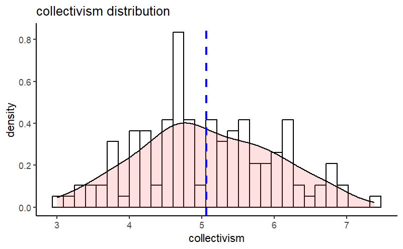

```r
library(ggplot2)
ggplot(IRP, aes(x=meancollectivism)) +
   geom_histogram(aes(y=..density..), colour="black", fill="white")+
 geom_density(alpha=.2, fill="#FF6666") +
  geom_vline(aes(xintercept=mean(meancollectivism)),
            color="blue", linetype="dashed", size=1) +
   labs(title="collectivism distribution",x="collectivism", y = "density")+
  theme_classic()
```

```r
#perfectionism statistics

describe(IRP$meanperfectionism)
```

```
IRP$meanperfectionism
       n  missing distinct     Info     Mean      Gmd      .05
     127        0       27    0.996    3.599   0.7569    2.538
     .10      .25      .50      .75      .90      .95
   2.825    3.125    3.625    3.938    4.375    4.762

lowest : 1.875 2.25  2.375 2.5   2.625, highest: 5.125 5.375 5.5   5.75  5.875
```

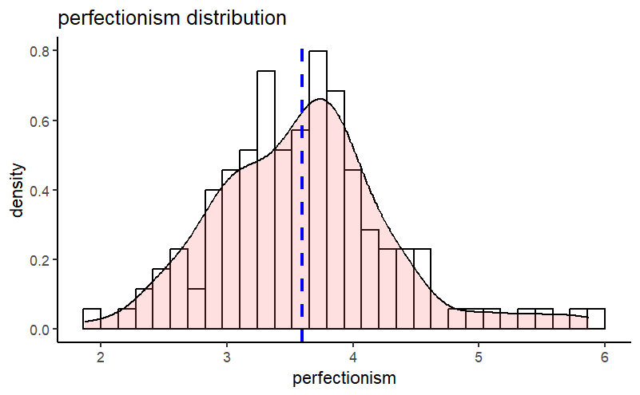

```r
library(ggplot2)
ggplot(IRP, aes(x=meanperfectionism)) +
   geom_histogram(aes(y=..density..), colour="black", fill="white")+
 geom_density(alpha=.2, fill="#FF6666") +
  geom_vline(aes(xintercept=mean(meanperfectionism)),
            color="blue", linetype="dashed", size=1) +
   labs(title="perfectionism distribution",x="perfectionism", y = "density")+
  theme_classic()
```

```r
#impression management statistics

describe(IRP$meanim)
```

```
IRP$meanim
       n  missing distinct     Info     Mean      Gmd      .05
     127        0       12    0.978   0.5229    0.138   0.3529
     .10      .25      .50      .75      .90      .95
  0.3529   0.4412   0.5294   0.5882   0.7059   0.7471

0.235294117647059 (1, 0.008), 0.294117647058824 (3, 0.024),
0.352941176470588 (12, 0.094), 0.411764705882353 (16, 0.126),
0.470588235294118 (27, 0.213), 0.529411764705882 (23, 0.181),
0.588235294117647 (16, 0.126), 0.647058823529412 (15, 0.118),
0.705882352941177 (7, 0.055), 0.764705882352941 (5, 0.039),
0.823529411764706 (1, 0.008), 0.882352941176471 (1, 0.008)

For the frequency table, variable is rounded to the nearest 0
```

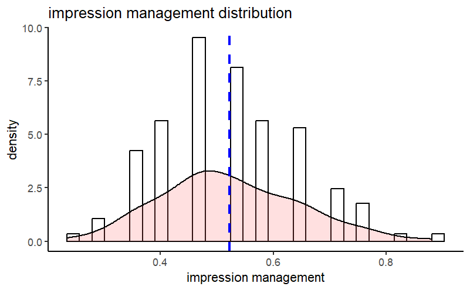

```r
library(ggplot2)
ggplot(IRP, aes(x=meanim)) +
   geom_histogram(aes(y=..density..), colour="black", fill="white")+
 geom_density(alpha=.2, fill="#FF6666") +
  geom_vline(aes(xintercept=mean(meanim)),
            color="blue", linetype="dashed", size=1) +
   labs(title="impression management distribution",x="impression management", y = "density")+
  theme_classic()
```

```r
#life satisfaction statistics

describe(IRP$meanls)
```

```
IRP$meanls
       n  missing distinct     Info     Mean      Gmd      .05
     127        0       21    0.994    3.995    1.044      2.6
     .10      .25      .50      .75      .90      .95
     2.8      3.2      4.0      4.6      5.0      5.4

lowest : 2.2 2.6 2.8 3   3.2, highest: 5.8 6   6.4 6.8 7
```

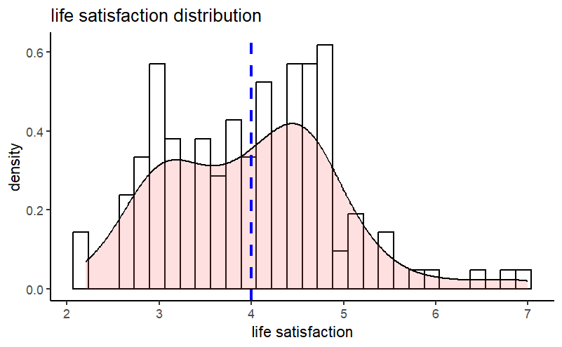

```r
library(ggplot2)
ggplot(IRP, aes(x=meanls)) +
   geom_histogram(aes(y=..density..), colour="black", fill="white")+
 geom_density(alpha=.2, fill="#FF6666") +
  geom_vline(aes(xintercept=mean(meanls)),
            color="blue", linetype="dashed", size=1) +
   labs(title="life satisfaction distribution",x="life satisfaction", y = "density")+
  theme_classic()
```

descriptive statistics for collectivism

```r
favstats(IRP$meancollectivism)
```

|  | min | Q1 | median | Q3 | max | mean | sd | n | missing |
| --- | --- | --- | --- | --- | --- | --- | --- | --- | --- |
|  | 3 | 4.5 | 5 | 5.75 | 7.375 | 5.060039 | 0.9343333 | 127 | 0 |

```r
kurtosis(IRP$meancollectivism)
```

```
[1] 2.43715
```

```r
skew(IRP$meancollectivism)
```

```
[1] 0.09731137
```

descriptive statistics for perfectionism

```r
favstats(IRP$meanperfectionism)
```

|  | min | Q1 | median | Q3 | max | mean | sd | n | missing |
| --- | --- | --- | --- | --- | --- | --- | --- | --- | --- |
|  | 1.875 | 3.125 | 3.625 | 3.9375 | 5.875 | 3.599409 | 0.6908448 | 127 | 0 |

```r
kurtosis(IRP$meanperfectionism)
```

```
[1] 4.136059
```

```r
skew(IRP$meanperfectionism)
```

```
[1] 0.5764514
```

descriptive statistics for impression management

```r
favstats(IRP$meanim)
```

|  | min | Q1 | median | Q3 | max | mean | sd | n | missing |
| --- | --- | --- | --- | --- | --- | --- | --- | --- | --- |
|  | 0.2352941 | 0.4411765 | 0.5294118 | 0.5882353 | 0.8823529 | 0.5229273 | 0.1229497 | 127 | 0 |

```r
kurtosis(IRP$meanim)
```

```
[1] 2.848452
```

```r
skew(IRP$meanim)
```

```
[1] 0.3209641
```

descriptive statistics for life satisfaction

```r
favstats(IRP$meanls)
```

|  | min | Q1 | median | Q3 | max | mean | sd | n | missing |
| --- | --- | --- | --- | --- | --- | --- | --- | --- | --- |
|  | 2.2 | 3.2 | 4 | 4.6 | 7 | 3.995276 | 0.9317894 | 127 | 0 |

```r
kurtosis(IRP$meanls)
```

```
[1] 3.328684
```

```r
skew(IRP$meanls)
```

```
[1] 0.4264431
```

#Creating measurement model- SEM

*Latent variable 1: Collectivism* measured by the INDCOL (Triandis & Gelfand, 1998), this included 4 items on horizontal collectivism and 4 items on vertical collectivism. Items were answered on a 9-point likert scale, 1 being completely disagree/ never, and 9 being completely agree/always. Vertical collectivism focuses on acceptance of hierarchy and authority, whilst horizontal collectivism emphasizes equality, cooperation, and shared responsibilities within social groups. Both of these dimensions will form our latent collectivism variable.

items for latent colllectivism include: HC1, HC2, HC3, HC4, VC1, VC2, VC3, VC4.

*Latent variable 2: Impression management* measured by the SDS-17 (Stöber, 2001), this included 17 items on a 2-point likert scale ‘true’ and false’. True was coded as 1 and false as 0, questions IM1, IM4, IM6, IM7, IM11, IM15, and IM17 were reverse keyed. The instrument was designed to measure impression management and self-deception, impression management can be understood as the deliberate effort to shape perceptions, behaviors, and expressions to convey a particular image or impression to others, often aligned with personal or situational objectives. It plays a significant role in social interactions, self-presentation, and how individuals are perceived in various contexts.

items for latent impression management include: IM1, IM2, IM3, IM4, IM5, IM6, IM7, IM8, IM9, IM10, IM11, IM12, IM13, IM14, IIM15, IM16, and IM17.

*Latent variable 3: Perfectionism* measured by the APS-R, (Slaney et al., 2001). This included 8 items on order, discrepancy, and high standards. Items were answered on a 6-point Likert scale, 1 being completely disagree abd 6 being completely agree. These dimensions align with the broader framework of perfectionism, emphasizing the tendencies related to setting high standards for oneself and others, along with concerns and anxieties surrounding mistakes or imperfections. The APS provides insights into different aspects of perfectionism.

Items for latent perfectionism include: P1, P2, P3, P4, P5, P6, P7, P8.

*Latent variable 4: Life satisfaction* measured by the SWLS (Diener et al., 1985). This included 5 items on a 7-point likert scale. 1 being completely disagree and 7 being completely agree. Life satisfaction refers to an individual’s overall evaluation or subjective judgment of their life as a whole. It encompasses an individual’s cognitive assessment and emotional appraisal of various domains of their life.

Items for latent life satisfaction: LS1, LS2, LS3, LS4, LS5.

```r
measurement.model <- "
impression_management=~ 1*IM1 + IM2 + IM3 + IM4 + IM5 + IM6 + IM7 + IM8 + IM9 + IM10 + IM11 + IM12 + IM13 + IM14 + IM15 + IM16 + IM17
collectivism=~ 1*HC1 + HC2 + HC3 + HC4 + VC1 + VC2 + VC3 + VC4
perfectionism=~ 1*P1 + P2 + P3 + P4 + P5 + P6 + P7 + P8
life_satisfaction=~ 1*LS1 + LS2 + LS3 + LS4 + LS5"
```

Fit indexes and model parameters

```r
measurement.model.fit <- cfa(measurement.model, data=IRP)
summary(measurement.model.fit, fit.measures=TRUE, standardized=TRUE)
```

```
lavaan 0.6.17 ended normally after 263 iterations

  Estimator                                         ML
  Optimization method                           NLMINB
  Number of model parameters                        82

  Number of observations                           127

Model Test User Model:

  Test statistic                               796.975
  Degrees of freedom                               659
  P-value (Chi-square)                           0.000

Model Test Baseline Model:

  Test statistic                               878.918
  Degrees of freedom                               703
  P-value                                        0.000

User Model versus Baseline Model:

  Comparative Fit Index (CFI)                    0.216
  Tucker-Lewis Index (TLI)                       0.163

Loglikelihood and Information Criteria:

  Loglikelihood user model (H0)              -7158.384
  Loglikelihood unrestricted model (H1)      -6759.897

  Akaike (AIC)                               14480.768
  Bayesian (BIC)                             14713.991
  Sample-size adjusted Bayesian (SABIC)      14454.672

Root Mean Square Error of Approximation:

  RMSEA                                          0.041
  90 Percent confidence interval - lower         0.029
  90 Percent confidence interval - upper         0.050
  P-value H_0: RMSEA <= 0.050                    0.941
```

[output cut: 194 more lines]

```
    2.427    0.907
    2.858    0.992
    2.934    0.971
    2.781    0.977
    2.787    0.980
    3.383    0.996
    5.964    1.581
    3.898    1.000
    3.730    1.046
    3.824    1.016
    4.244    1.094
    1.000    1.000
       NA       NA
    1.000    1.000
       NA       NA
```

The Standardized Root Mean Square Residual (SRMR) is 0.085, which is above the commonly recommended threshold of 0.08, indicating some discrepancy between the observed and model-implied covariance matrices. The Root Mean Square Error of Approximation (RMSEA) is 0.041, falling within an acceptable range, supported by its 90 percent confidence interval (CI) of 0.029 to 0.050. However, the p-values associated with the null hypotheses that RMSEA is less than or equal to 0.050 and greater than or equal to 0.080 are 0.941 and 0.000, respectively. The Comparative Fit Index (CFI) and Tucker-Lewis Index (TLI) both fall considerably below the ideal threshold of 0.95, indicating poor fit. Overall, while the RMSEA suggests reasonable fit, the SRMR, CFI, and TLI indicate significant room for improvement.

- impression_management- items with low loadings, such as “IM3,”IM2”, “IM4,” “IM9,” “IM10,” “IM13,” “IM14,” and “IM15.”
- collectivism- items with low loadings or high standard errors. In this case, “HC2,” “HC3,” “HC4,” “VC1,” “VC3,” and “VC4”
- perfectionism- items with low loadings or high standard errors, “P2” and “P8” have low loadings and/or high standard errors
- life_satisfaction- items with low loadings or high standard errors “LS3,” and “LS5” have low loadings and/or high standard errors

building second measurement model Now that we’ve obtained items which do not capture the underlying construct, we will remove them from our measurement model. Removing items with low factor loadings from a measurement model or CFA can lead to a more parsimonious, valid, and interpretable model. It enhances construct validity, refines our measurement model, avoids model misspecification, and improves interpretability.

```r
measurement.model2 <- "
impression_management=~ 1*IM1 + IM5 + IM6 + IM7 + IM8 + IM11 + IM12 + IM16 + IM17
collectivism=~ 1*HC1 + VC2
perfectionism=~ 1*P1 + P3 + P4 + P5 + P6 + P7
life_satisfaction=~ 1*LS1 + LS2 + LS4"
```

```r
measurement.model.fit2 <- cfa(measurement.model2, data=IRP)
summary(measurement.model.fit2, fit.measures=TRUE, standardized=TRUE)
```

```
lavaan 0.6.17 ended normally after 138 iterations

  Estimator                                         ML
  Optimization method                           NLMINB
  Number of model parameters                        46

  Number of observations                           127

Model Test User Model:

  Test statistic                               145.036
  Degrees of freedom                               164
  P-value (Chi-square)                           0.854

Model Test Baseline Model:

  Test statistic                               205.411
  Degrees of freedom                               190
  P-value                                        0.211

User Model versus Baseline Model:

  Comparative Fit Index (CFI)                    1.000
  Tucker-Lewis Index (TLI)                       2.426

Loglikelihood and Information Criteria:

  Loglikelihood user model (H0)              -3665.247
  Loglikelihood unrestricted model (H1)      -3592.729

  Akaike (AIC)                                7422.494
  Bayesian (BIC)                              7553.327
  Sample-size adjusted Bayesian (SABIC)       7407.855

Root Mean Square Error of Approximation:

  RMSEA                                          0.000
  90 Percent confidence interval - lower         0.000
  90 Percent confidence interval - upper         0.024
  P-value H_0: RMSEA <= 0.050                    1.000
```

[output cut: 122 more lines]

```
    4.791    0.743
    5.413    0.988
    3.585    1.118
    2.706    1.012
    3.467    1.203
    3.480    1.151
    2.850    1.001
    3.007    1.058
    3.665    0.971
    3.686    0.946
    1.795    0.477
       NA       NA
    1.000    1.000
       NA       NA
    1.000    1.000
```

#composite reliability

```r
# save standardised factor loadings in object s1
sl <- standardizedSolution(measurement.model.fit2)

sl <- drop_na(sl, est.std)

# extract from s1 standardised estimates (est.std) form only parent conditional regard
sl <- sl$est.std[sl$lhs == "impression_management"]


# calculate the residual variances
re <- 1 - sl^2


# calculate the composite reliability
sum(sl)^2 / (sum(sl)^2 + sum(re))
```

```
[1] 0.06361881
```

composite reliability scores should ideally be above 0.7 to ensure sufficient reliability. A score as low as 0.06 indicates a significant lack of reliability.

```r
# save standardised factor loadings in object s1
sl <- standardizedSolution(measurement.model.fit2)

# extract from s1 standardised estimates (est.std) form only parent conditional regard
sl <- sl$est.std[sl$lhs == "collectivism"]

# calculate the residual variances
re <- 1 - sl^2


# calculate the composite reliability
sum(sl)^2 / (sum(sl)^2 + sum(re))
```

```
[1] 0.2744093
```

While this score falls below the ideal threshold of 0.7, it suggests a somewhat better level of reliability compared to the impression management measure.

```r
# save standardised factor loadings in object s1
sl <- standardizedSolution(measurement.model.fit2)

sl <- drop_na(sl, est.std)

# extract from s1 standardised estimates (est.std) form only parent conditional regard
sl <- sl$est.std[sl$lhs == "perfectionism"]

# calculate the residual variances
re <- 1 - sl^2

# calculate the composite reliability
sum(sl)^2 / (sum(sl)^2 + sum(re))
```

```
[1] 0.04575225
```

A composite reliability score of 0.05 for perfectionism indicates very poor reliability.

```r
# save standardised factor loadings in object s1
sl <- standardizedSolution(measurement.model.fit2)

# extract from s1 standardised estimates (est.std) form only parent conditional regard
sl <- sl$est.std[sl$lhs == "life_satisfaction"]

# calculate the residual variances
re <- 1 - sl^2

# calculate the composite reliability
sum(sl)^2 / (sum(sl)^2 + sum(re))
```

```
[1] 0.01867697
```

#Discussion

When confronted with a scenario featuring perfect fit indexes alongside poor composite reliability in a measurement model, careful consideration of several factors becomes paramount. While the perfect fit indexes may initially suggest that the model aligns well with the data, the presence of poor composite reliability highlights significant concerns regarding the validity of the measurement model. Poor composite reliability can arise from various factors, including poorly formulated items, or conceptual complexities within the constructs being measured. Additionally, methodological issues such as response biases could also contribute to poor reliability.

Moreover, understanding the potential impact of poor reliability on the interpretation of findings is crucial; unreliable measures can yield inconsistent or unreliable results, undermining the validity of any conclusions drawn from the SEM. Ultimately, while achieving perfect fit indexes is desirable, it should not overshadow the importance of ensuring measurement quality and validity. Striking a balance between model fit and measurement reliability is essential for producing robust and credible research findings.

#visualizing the CFA

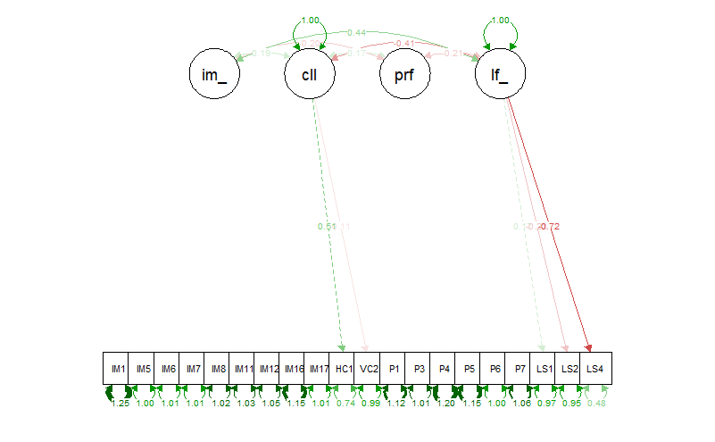

```r
semPaths(measurement.model.fit2, "std")
```

#error-free correlations

```r
IRP <- IRP %>%
  mutate(meanim = (IM1 + IM5 + IM6 + IM7 + IM8 + IM11 + IM12 + IM16 + IM17)/9)
IRP <- IRP %>%
  mutate(meancollectivism = (HC1 + VC2)/2)
IRP <- IRP %>%
  mutate(meanperfectionism = (P1 + P2 + P3 + P4 + P5 + P6 + P7)/7)
IRP <- IRP %>%
  mutate(meanls = (LS1 + LS4)/2)
rcorr(as.matrix(IRP[,c("meanim","meancollectivism", "meanperfectionism", "meanls")], type="pearson"))
```

```
                  meanim meancollectivism meanperfectionism
meanim              1.00             0.09             -0.05
meancollectivism    0.09             1.00             -0.03
meanperfectionism  -0.05            -0.03              1.00
meanls              0.02             0.05              0.01
                  meanls
meanim              0.02
meancollectivism    0.05
meanperfectionism   0.01
meanls              1.00

n= 127


P
                  meanim meancollectivism meanperfectionism
meanim                   0.3165           0.5784
meancollectivism  0.3165                  0.7792
meanperfectionism 0.5784 0.7792
meanls            0.8002 0.5963           0.8825
                  meanls
meanim            0.8002
meancollectivism  0.5963
meanperfectionism 0.8825
meanls
```

- The correlation between “Impression Management” and “Collectivism” is 0.09, suggesting a weak positive relationship between these variables.
- The correlation between “Impression Management” and “Perfectionism” is -0.05, indicating a weak negative relationship, though this correlation is closer to zero, suggesting little association between these variables.
- The correlation between “Impression Management” and “Life Satisfaction” is 0.02, indicating a very weak positive relationship, essentially no correlation.
- The correlation between “Collectivism” and “Perfectionism” is -0.03, showing a very weak negative relationship.
- The correlation between “Collectivism” and “Life Satisfaction” is 0.05, suggesting a weak positive relationship.
- The correlation between “Perfectionism” and “Life Satisfaction” is 0.01, indicating a very weak positive relationship, essentially no correlation.

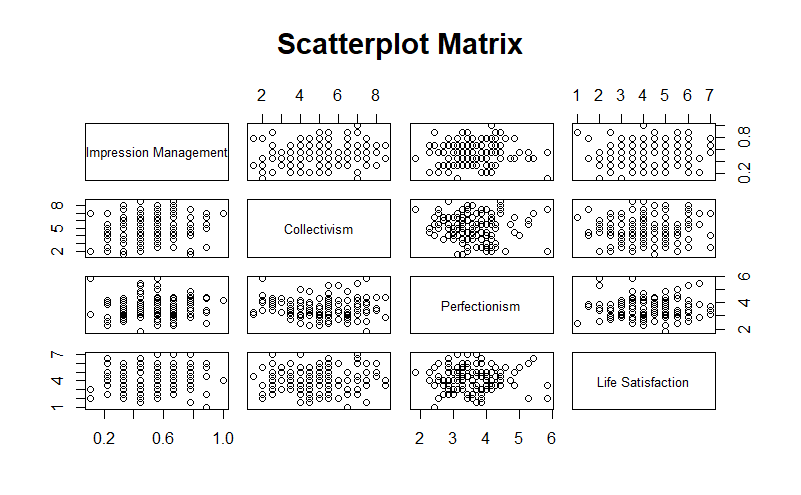

```r
library(corrplot)
library(dplyr)

# Rename columns in the data frame
IRP_renamed <- IRP %>%
  rename("Impression Management" = meanim,
         "Collectivism" = meancollectivism,
         "Perfectionism" = meanperfectionism,
         "Life Satisfaction" = meanls)

# Calculate the correlation matrix
cor_matrix <- cor(IRP_renamed[, c("Impression Management", "Collectivism", "Perfectionism", "Life Satisfaction")])

# Create a scatterplot matrix
pairs(IRP_renamed[, c("Impression Management", "Collectivism", "Perfectionism", "Life Satisfaction")],
      main = "Scatterplot Matrix")
```

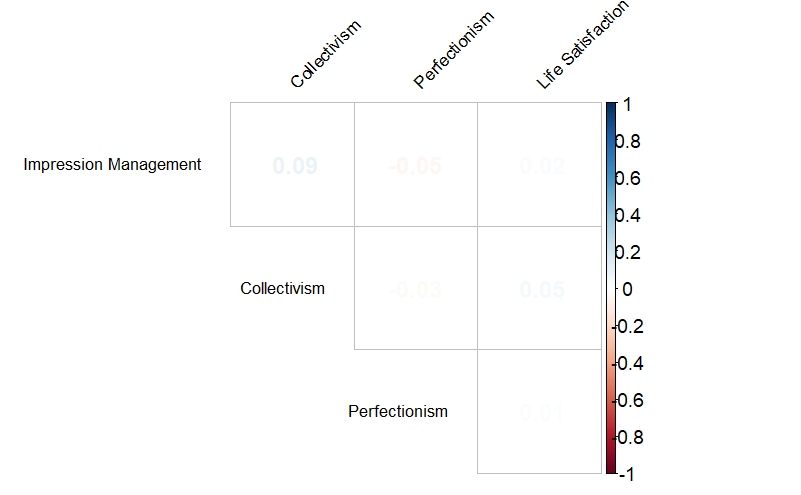

```r
# Display correlation coefficients on the scatterplot matrix with custom text properties
corrplot(cor_matrix, method = "number", type = "upper", tl.col = "black", tl.srt = 45,
         addCoef.col = "blue", # Change color of correlation coefficients
         diag = FALSE, # Hide diagonal elements
         tl.offset = 1, # Offset text
         number.cex = 1, # Adjust size of correlation coefficient text
         tl.cex = 0.7) # Adjust size of variable name text
```

```r
NA
NA
```

##Testing the Full Latent Variable Structural Equation Model (SEM)

just-identified model- hypothesized full mediation

I am building an SEM where collectivism is my predictor, life satisfaction is my outcome variable, and impression management/ perfectionism are my mediators.

```r
structural.model <- "
# measurement portion of model
impression_management=~ 1*IM1 + IM5 + IM6 + IM7 + IM8 + IM11 + IM12 + IM16 + IM17
collectivism=~ 1*HC1 + VC2
perfectionism=~ 1*P1 + P3 + P4 + P5 + P6 + P7
life_satisfaction=~ 1*LS1 + LS2 + LS4
# structural portion of model
perfectionism ~ a1*collectivism
impression_management ~ a2*collectivism
life_satisfaction ~ b1*perfectionism
life_satisfaction~ b2*impression_management

#the indirect effects
a1b1 := a1*b1
a2b2 := a2*b2"
```

fitting model

```r
structural.model.fit <- sem(structural.model, data=IRP, se = "bootstrap", bootstrap = 100)
summary(structural.model.fit, fit.measures=TRUE, standardized=TRUE)
```

```
Warning: lavaan WARNING: fit measures not available if model did not converge
```

```
lavaan 0.6.17 did NOT end normally after 672 iterations
** WARNING ** Estimates below are most likely unreliable

  Estimator                                         ML
  Optimization method                           NLMINB
  Number of model parameters                        44

  Number of observations                           127


Parameter Estimates:

  Standard errors                            Bootstrap
  Number of requested bootstrap draws              100
  Number of successful bootstrap draws               0

Latent Variables:
                           Estimate  Std.Err  z-value  P(>|z|)
  impression_management =~
    IM1                       1.000
    IM5                       0.000       NA
    IM6                       0.000       NA
    IM7                       0.000       NA
    IM8                       0.000       NA
    IM11                      0.000       NA
    IM12                     -0.000       NA
    IM16                     -0.000       NA
    IM17                     -0.000       NA
  collectivism =~
    HC1                       1.000
    VC2                      -0.001       NA
  perfectionism =~
    P1                        1.000
    P3                      233.261       NA
    P4                     6185.051       NA
    P5                     2252.365       NA
    P6                     -942.394       NA
    P7                     1898.607       NA
  life_satisfaction =~
    LS1                       1.000
```

[output cut: 90 more lines]

```
    3.773     1.000
    3.608     0.919
    2.309     0.616
    1.000     1.000
    1.000     1.000
    1.000     1.000
    0.959     0.959

Defined Parameters:
                   Estimate  Std.Err  z-value  P(>|z|)
    a1b1              0.000
    a2b2             -0.000
   Std.lv  Std.all
    0.004     0.004
   -0.000    -0.000
```

#Discussion

Despite the convergence issues, we can still calculate the total effects (indirect effects) a1b1 and a2b2. For a1b1, since the estimate for a1 is 0, the total effect is also 0. For a2b2, the estimate for a2 is 0.001, and since the estimate for b2 is 0, the total effect is also 0. This indicates that there is no indirect effect of collectivism on life satisfaction through either perfectionism or impression management in the hypothesized model model.

It’s important to interpret these results with caution due to the convergence issues. Despite efforts to adjust optimization parameters, provide starting values, and run single mediations, convergence was not achieved. This suggests that the model may be too complex or that the optimization algorithm may be struggling to find a suitable solution within the specified constraints. Consequently, the estimates and interpretations should be considered tentative until convergence can be achieved and the model’s stability confirmed.

```r
library(lavaan)

# Extract parameter estimates and bootstrap confidence intervals
parameterEstimates(structural.model.fit, boot.ci = TRUE)
```

```
Error in parameterEstimates(structural.model.fit, boot.ci = TRUE) :
  !is.null(BOOT) is not TRUE
```

```r
lavInspect(structural.model.fit, what = "rsquare")
```

```
                  IM1                   IM5
                   NA                 0.000
                  IM6                   IM7
                0.000                 0.000
                  IM8                  IM11
                0.000                 0.000
                 IM12                  IM16
                0.000                 0.000
                 IM17                   HC1
                0.000                    NA
                  VC2                    P1
                0.000                 0.000
                   P3                    P4
                0.001                 0.665
                   P5                    P6
                0.083                 0.016
                   P7                   LS1
                0.063                 0.000
                  LS2                   LS4
                0.081                 0.384
impression_management         perfectionism
                0.000                 0.000
    life_satisfaction
                0.041
```

#single-mediator models

Due to issues with convergence- here I conduct single mediation SEM’s to try address these convergence issues.

Here I am conducted a full mediation with only perfectionism as my mediator

```r
structural.model.2 <- "
# measurement portion of model
collectivism=~ 1*HC1 + VC2
perfectionism=~ 1*P1 + P3 + P4 + P5 + P6 + P7
life_satisfaction=~ 1*LS1 + LS4
# structural portion of model
perfectionism ~ a*collectivism
life_satisfaction ~ b*perfectionism

#the indirect effects
ab := a*b"
```

Various strategies such as adjusting optimization parameters, providing starting values, and simplifying the model to address convergence issues.

```r
# Run the SEM model with bootstrapping
structural.model.fit2 <- sem(
  structural.model.2,
  data = IRP,
  se = "bootstrap",  # Specify bootstrapping
  bootstrap = 100,
  control = list(maxiter = 1000)  # Increase max iterations
)
# Obtain summary of the model with fit measures
summary_fit <- summary(structural.model.fit2, fit.measures = TRUE)

# Extract parameter estimates with bootstrap confidence intervals
parameter_estimates <- summary_fit$Boot.estimates

# Print parameter estimates with bootstrap confidence intervals
print(parameter_estimates)
```

[output not shown]

Has not seemed to fix convergence issues.

##over-identified model with direct path added

Similar to my just-identified model, my predictor is collectivism, outcome variable is life satisfaction, my mediators are perfectionism/ impression management, however now we are adding a direct path between collectivism and life satisfaction, conducting a partial mediation.

```r
sem.model2 <- "
#measurement portion of model
impression_management=~ 1*IM1 + IM2 + IM5 + IM6 + IM7 + IM8 + IM11 + IM12 + IM16 + IM17
collectivism=~ 1*HC1 + VC2
perfectionism=~ 1*P1 + P3 + P4 + P5 + P6 + P7
life_satisfaction=~ 1*LS1 + LS4
# structural portion of model
perfectionism ~ a1*collectivism
impression_management ~ a2*collectivism
life_satisfaction ~ b1*perfectionism
life_satisfaction~ b2*impression_management
life_satisfaction ~ c*collectivism  # Additional direct path

#the indirect effects
a1b1 := a1*b1
a2b2 := a2*b2"
```

#fit over-identified model

```r
sem.model.fit2 <- sem(sem.model2, data=IRP,se = "bootstrap", bootstrap = 100)
summary(sem.model.fit2, fit.measures=TRUE, standardized=TRUE)
```

```
lavaan 0.6.17 did NOT end normally after 4183 iterations
** WARNING ** Estimates below are most likely unreliable

  Estimator                                         ML
  Optimization method                           NLMINB
  Number of model parameters                        45

  Number of observations                           127


Parameter Estimates:

  Standard errors                            Bootstrap
  Number of requested bootstrap draws              100
  Number of successful bootstrap draws               0

Latent Variables:
                           Estimate   Std.Err  z-value
  impression_management =~
    IM1                        1.000
    IM2                        0.836       NA
    IM5                       -0.469       NA
    IM6                       -0.654       NA
    IM7                       -0.469       NA
    IM8                        0.285       NA
    IM11                       0.073       NA
    IM12                       0.621       NA
    IM16                       0.617       NA
    IM17                      -0.058       NA
  collectivism =~
    HC1                        1.000
    VC2                       -0.000       NA
  perfectionism =~
    P1                         1.000
    P3                        62.748       NA
    P4                      3212.780       NA
    P5                       351.536       NA
    P6                      -127.562       NA
    P7                       313.991       NA
  life_satisfaction =~
```

[output cut: 92 more lines]

```
     2.781    0.978
     3.707    0.988
     1.108    0.295
     0.419    0.419
     1.000    1.000
     1.000    1.000
  -382.084 -382.084

Defined Parameters:
                   Estimate   Std.Err  z-value  P(>|z|)
    a1b1              -0.000
    a2b2               0.137
   Std.lv   Std.all
    -0.000   -0.000
    23.063   23.063
```

```r
lavInspect(sem.model.fit2, what = "rsquare")
```

```
                  IM1                   IM2
                0.000                 0.000
                  IM5                   IM6
                0.000                 0.000
                  IM7                   IM8
                0.000                 0.000
                 IM11                  IM12
                0.000                 0.000
                 IM16                  IM17
                0.000                 0.000
                  HC1                   VC2
                   NA                 0.000
                   P1                    P3
                0.000                 0.001
                   P4                    P5
                   NA                 0.026
                   P6                    P7
                0.004                 0.022
                  LS1                   LS4
                0.012                 0.705
impression_management         perfectionism
                0.581                 0.000
    life_satisfaction
                   NA
```

#Discussion

Collectivism exhibits a null coefficient on perfectionism (a1). Perfectionism(b1) exhibits a negative coefficient (-9.848), implying that increased levels of perfectionism are associated with decreased life satisfaction, holding other variables constant.Whilst perfectionism seems to predict negative levels of life satisfaction, the indirect path (a1b1) between collectivism and life satisfaction via perfectionism is null.

However, these interpretations are most likely unreliable and must be approached with caution due to the lack of bootstrapping and the warning message regarding convergence issues. The absence of bootstrapping means we cannot assess the stability and reliability of the coefficients, while the convergence issues raise doubts about the accuracy of the parameter estimates and their standard errors. Consequently, these methodological concerns underscore the need for further validation and replication of the findings using robust statistical techniques. Addressing these issues is crucial to ensure the reliability and validity of the results and to draw more substantive conclusions regarding the relationships between the variables in question.

# supplementary analysis- single regressions

Here I am analyzing each path in my SEM as single regressions to capture any particular prominent relationships. Due to the inconclusivity of my mediated SEM’s, by conducting single regression SEM’s helps achieve convergence to a certain degree and allows me to extract more meaningful and valid findings.

Here I am conducting a single regression between collectivism and impression management

```r
col.im.reg <-"
# measurement portion of model
impression_management=~ 1*IM1 + IM2 + IM5 + IM6 + IM7 + IM8 + IM11 + IM12 + IM16 + IM17
collectivism=~ 1*HC1 + VC2
#structural portion
impression_management~collectivism"
```

```r
col.im.fit <- sem(col.im.reg, data=IRP,se = "bootstrap", bootstrap = 100)
summary(col.im.fit, fit.measures=TRUE, standardized=TRUE)
```

```
lavaan 0.6.17 ended normally after 158 iterations

  Estimator                                         ML
  Optimization method                           NLMINB
  Number of model parameters                        25

  Number of observations                           127

Model Test User Model:

  Test statistic                                47.035
  Degrees of freedom                                53
  P-value (Chi-square)                           0.704

Model Test Baseline Model:

  Test statistic                                69.034
  Degrees of freedom                                66
  P-value                                        0.375

User Model versus Baseline Model:

  Comparative Fit Index (CFI)                    1.000
  Tucker-Lewis Index (TLI)                       3.448

Loglikelihood and Information Criteria:

  Loglikelihood user model (H0)              -1493.004
  Loglikelihood unrestricted model (H1)      -1469.486

  Akaike (AIC)                                3036.008
  Bayesian (BIC)                              3107.113
  Sample-size adjusted Bayesian (SABIC)       3028.052

Root Mean Square Error of Approximation:

  RMSEA                                          0.000
  90 Percent confidence interval - lower         0.000
  90 Percent confidence interval - upper         0.045
  P-value H_0: RMSEA <= 0.050                    0.971
```

[output cut: 68 more lines]

```
   Std.lv  Std.all
    0.254    1.017
    0.251    1.008
    0.252    1.008
    0.252    1.021
    0.268    1.087
    0.250    1.022
    0.294    1.189
    0.250    1.000
    0.248    1.000
    0.311    1.246
    5.633    0.873
    5.348    0.977
       NA       NA
    1.000    1.000
```

bootstrapping still not entirely running

```r
library(lavaan)

# Extract parameter estimates and bootstrap confidence intervals
parameterEstimates(col.im.fit, boot.ci = TRUE)
```

```
Error in parameterEstimates(col.im.fit, boot.ci = TRUE) :
  boot.ci.type %in% c("norm", "basic", "perc", "bca.simple", "bca") is not TRUE
```

```r
lavInspect(col.im.fit, what = "rsquare")
```

```
                  IM1                   IM2
               -0.017                -0.008
                  IM5                   IM6
               -0.008                -0.021
                  IM7                   IM8
               -0.087                -0.022
                 IM11                  IM12
               -0.189                 0.000
                 IM16                  IM17
                0.000                -0.246
                  HC1                   VC2
                0.127                 0.023
impression_management
                   NA
```

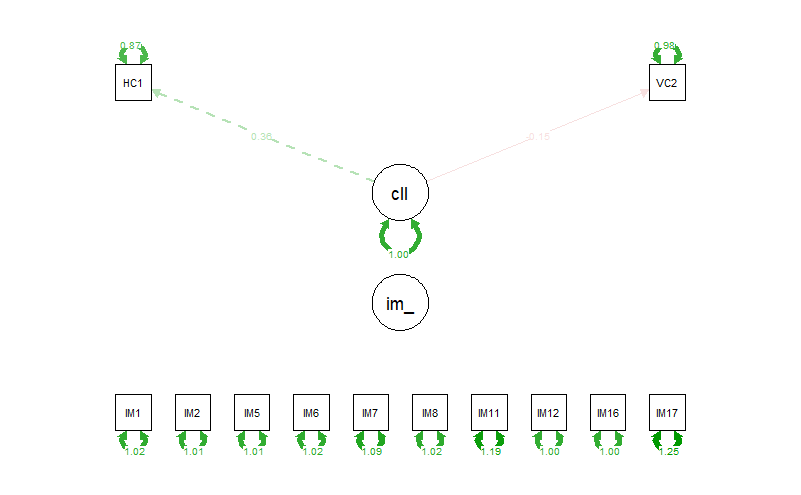

```r
semPaths(col.im.fit, "std")
```

#Discussion The regression coefficient (β) for the relationship between impression management and collectivism is -0.016, with a p-value of 0.927. This suggests that there is no statistically significant association between these variables based on the regression analysis. In other words, the evidence from the regression analysis does not support the presence of a meaningful relationship between impression management and collectivism in the context of the study.

Both RMSEA and SRMR values, though indicating good fit to the data,the TLI value of 3.448 is unusually high and may indicate potential issues with model identification or specification. The CFI value of 1.000 indicates perfect fit between the specified model and the data. This may indicate that other unmeasured or omitted variables in the model are driving the relationships of interest.

single regression between collectivism and perfectionism

```r
col.per.reg <-"
# measurement portion of model
perfectionism=~ 1*P1 + P3 + P4 + P5 + P6 + P7
collectivism=~ 1*HC1 + VC2
#structural portion
perfectionism~collectivism"
```

fitting model

```r
col.per.fit <- sem(col.per.reg, data=IRP,se = "bootstrap", bootstrap = 100)
summary(col.per.fit, fit.measures=TRUE, standardized=TRUE)
```

```
lavaan 0.6.17 ended normally after 87 iterations

  Estimator                                         ML
  Optimization method                           NLMINB
  Number of model parameters                        17

  Number of observations                           127

Model Test User Model:

  Test statistic                                19.725
  Degrees of freedom                                19
  P-value (Chi-square)                           0.411

Model Test Baseline Model:

  Test statistic                                39.877
  Degrees of freedom                                28
  P-value                                        0.068

User Model versus Baseline Model:

  Comparative Fit Index (CFI)                    0.939
  Tucker-Lewis Index (TLI)                       0.910

Loglikelihood and Information Criteria:

  Loglikelihood user model (H0)              -2064.651
  Loglikelihood unrestricted model (H1)      -2054.788

  Akaike (AIC)                                4163.302
  Bayesian (BIC)                              4211.653
  Sample-size adjusted Bayesian (SABIC)       4157.892

Root Mean Square Error of Approximation:

  RMSEA                                          0.017
  90 Percent confidence interval - lower         0.000
  90 Percent confidence interval - upper         0.080
  P-value H_0: RMSEA <= 0.050                    0.733
```

[output cut: 52 more lines]

```
   .HC1               6.142   43.253    0.142    0.887
   .VC2               5.136    2.645    1.942    0.052
   .perfectionism    -0.342   19.281   -0.018    0.986
    collectivism      0.309   43.401    0.007    0.994
   Std.lv  Std.all
    3.513    1.096
    2.765    1.033
    3.482    1.208
    3.606    1.193
    2.850    1.001
    2.940    1.034
    6.142    0.952
    5.136    0.938
       NA       NA
    1.000    1.000
```

```r
lavInspect(col.per.fit, what = "rsquare")
```

```
           P1            P3            P4            P5
       -0.096        -0.033        -0.208        -0.193
           P6            P7           HC1           VC2
       -0.001        -0.034         0.048         0.062
perfectionism
           NA
```

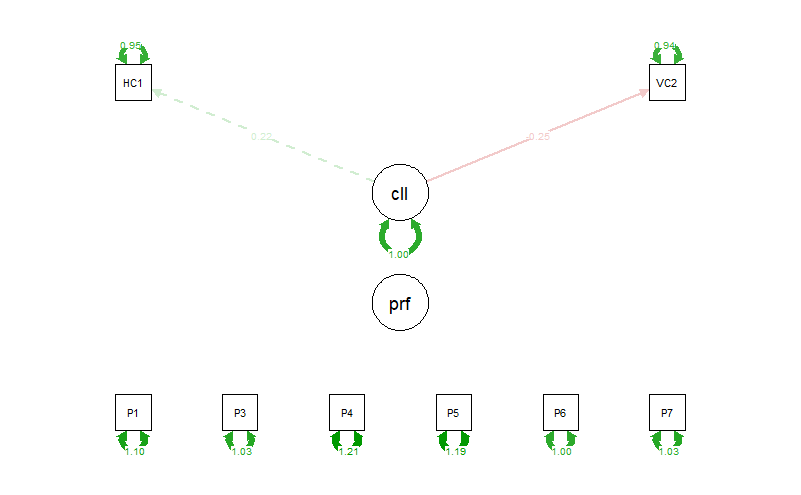

```r
semPaths(col.per.fit, "std")
```

#Dicussion

Regarding the regression analysis, the coefficient estimate for the relationship between perfectionism and collectivism is 0.338, with a standard error of 3.500 and a corresponding z-value of 0.097. The p-value associated with this coefficient is 0.923, indicating that the relationship between perfectionism and collectivism is not statistically significant at conventional levels of significance (e.g., α = 0.05). These findings suggest that variations in collectivism do not predict variations in perfectionism, and vice versa, based on the regression analysis.

single regression between perfectionism and life satisfaction

```r
per.ls.reg<-"
#measurement portion of model
perfectionism=~ 1*P1 + P3 + P4 + P5 + P6 + P7
life_satisfaction=~ 1*LS1 + LS4
#structural portion
life_satisfaction~ perfectionism"
```

```r
per.ls.fit <- sem(per.ls.reg, data=IRP,se = "bootstrap", bootstrap = 100)
summary(per.ls.fit, fit.measures=TRUE, standardized=TRUE)
```

```
lavaan 0.6.17 ended normally after 87 iterations

  Estimator                                         ML
  Optimization method                           NLMINB
  Number of model parameters                        17

  Number of observations                           127

Model Test User Model:

  Test statistic                                25.473
  Degrees of freedom                                19
  P-value (Chi-square)                           0.146

Model Test Baseline Model:

  Test statistic                                46.982
  Degrees of freedom                                28
  P-value                                        0.014

User Model versus Baseline Model:

  Comparative Fit Index (CFI)                    0.659
  Tucker-Lewis Index (TLI)                       0.497

Loglikelihood and Information Criteria:

  Loglikelihood user model (H0)              -2006.089
  Loglikelihood unrestricted model (H1)      -1993.352

  Akaike (AIC)                                4046.178
  Bayesian (BIC)                              4094.529
  Sample-size adjusted Bayesian (SABIC)       4040.768

Root Mean Square Error of Approximation:

  RMSEA                                          0.052
  90 Percent confidence interval - lower         0.000
  90 Percent confidence interval - upper         0.099
  P-value H_0: RMSEA <= 0.050                    0.438
```

[output cut: 52 more lines]

```
   .LS1               3.554    3.464    1.026    0.305
   .LS4               2.932    2.034    1.441    0.149
    perfectionism    -0.288    0.474   -0.607    0.544
   .life_satisfctn    0.235    3.530    0.066    0.947
   Std.lv  Std.all
    3.495    1.090
    2.711    1.013
    3.541    1.228
    3.509    1.161
    2.847    1.000
    3.031    1.066
    3.554    0.942
    2.932    0.779
       NA       NA
    1.069    1.069
```

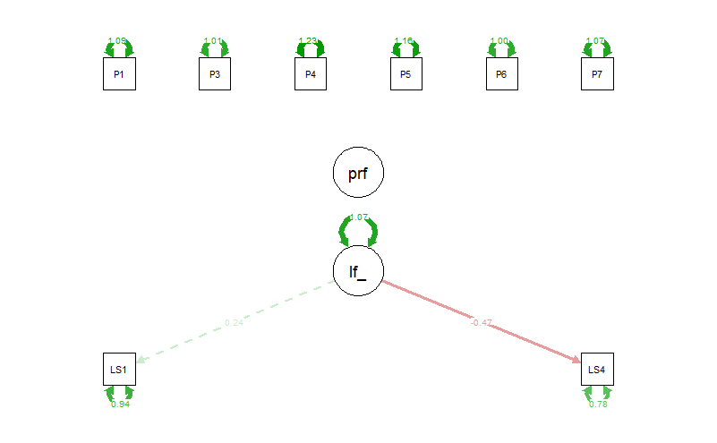

```r
semPaths(per.ls.fit, "std")
```

#Discussion

the coefficient estimate for the relationship between life satisfaction and perfectionism is 0.230, with a standard error of 0.848 and a corresponding z-value of 0.271. The associated p-value for this coefficient is 0.787, indicating that the relationship between life satisfaction and perfectionism is not statistically significant at conventional levels of significance (e.g., α = 0.05).

These results suggest that variations in perfectionism do not predict variations in life satisfaction, and vice versa, based on the regression analysis. In other words, the evidence from the regression analysis does not support the presence of a meaningful association between life satisfaction and perfectionism in the context of the study.

Regressions were also conducted between impression management and life satisfaction, and collectivism and life satisfaction, however bootstrapping did not run. Therefore there would be no added value in including those.